# DATA 607 IS 607 Project 2 part 3

Yohannes Deboch

March 3, 2019

```r
library(tidyr)
library(dplyr)
```

```r
library(ggplot2)
library(stringr)
```

Data 3 Population, total https://data.worldbank.org/indicator/SP.POP.TOTL

```r
pop <- read.csv("API_SP.POP.TOTL_DS2_en_csv_v2_10473719.csv", skip = 4)
```

View first few rows of the data

```r
head(pop)
```

```
##   Country.Name Country.Code    Indicator.Name Indicator.Code    X1960
## 1        Aruba          ABW Population, total    SP.POP.TOTL    54211
## 2  Afghanistan          AFG Population, total    SP.POP.TOTL  8996351
## 3       Angola          AGO Population, total    SP.POP.TOTL  5643182
## 4      Albania          ALB Population, total    SP.POP.TOTL  1608800
## 5      Andorra          AND Population, total    SP.POP.TOTL    13411
## 6   Arab World          ARB Population, total    SP.POP.TOTL 92490932
##      X1961    X1962     X1963     X1964     X1965     X1966     X1967
## 1    55438    56225     56695     57032     57360     57715     58055
## 2  9166764  9345868   9533954   9731361   9938414  10152331  10372630
## 3  5753024  5866061   5980417   6093321   6203299   6309770   6414995
## 4  1659800  1711319   1762621   1814135   1864791   1914573   1965598
## 5    14375    15370     16412     17469     18549     19647     20758
## 6 95044497 97682294 100411076 103239902 106174988 109230593 112406932
##       X1968     X1969     X1970     X1971     X1972     X1973     X1974
```

[output cut: 55 more lines]

Drop unnecessary variables

```r
pop <- pop %>%
    select("Country.Name",starts_with("X"),-X)
head(pop)
```

```
##   Country.Name    X1960    X1961    X1962     X1963     X1964     X1965
## 1        Aruba    54211    55438    56225     56695     57032     57360
## 2  Afghanistan  8996351  9166764  9345868   9533954   9731361   9938414
## 3       Angola  5643182  5753024  5866061   5980417   6093321   6203299
## 4      Albania  1608800  1659800  1711319   1762621   1814135   1864791
## 5      Andorra    13411    14375    15370     16412     17469     18549
## 6   Arab World 92490932 95044497 97682294 100411076 103239902 106174988
##       X1966     X1967     X1968     X1969     X1970     X1971     X1972
## 1     57715     58055     58386     58726     59063     59440     59840
## 2  10152331  10372630  10604346  10854428  11126123  11417825  11721940
## 3   6309770   6414995   6523791   6642632   6776381   6927269   7094834
## 4   1914573   1965598   2022272   2081695   2135479   2187853   2243126
## 5     19647     20758     21890     23058     24276     25559     26892
## 6 109230593 112406932 115680165 119016542 122398374 125807419 129269375
##       X1973     X1974     X1975     X1976     X1977     X1978     X1979
```

[output cut: 48 more lines]

Remove unncessary variable X2018

```r
pop <- pop %>%
    select(-X2018)
head(pop)
```

```
##   Country.Name    X1960    X1961    X1962     X1963     X1964     X1965
## 1        Aruba    54211    55438    56225     56695     57032     57360
## 2  Afghanistan  8996351  9166764  9345868   9533954   9731361   9938414
## 3       Angola  5643182  5753024  5866061   5980417   6093321   6203299
## 4      Albania  1608800  1659800  1711319   1762621   1814135   1864791
## 5      Andorra    13411    14375    15370     16412     17469     18549
## 6   Arab World 92490932 95044497 97682294 100411076 103239902 106174988
##       X1966     X1967     X1968     X1969     X1970     X1971     X1972
## 1     57715     58055     58386     58726     59063     59440     59840
## 2  10152331  10372630  10604346  10854428  11126123  11417825  11721940
## 3   6309770   6414995   6523791   6642632   6776381   6927269   7094834
## 4   1914573   1965598   2022272   2081695   2135479   2187853   2243126
## 5     19647     20758     21890     23058     24276     25559     26892
## 6 109230593 112406932 115680165 119016542 122398374 125807419 129269375
##       X1973     X1974     X1975     X1976     X1977     X1978     X1979
```

[output cut: 48 more lines]

Convert wide to long format

```r
pop <- gather(pop, "Year","Population",-Country.Name)
head(pop)
```

```
##   Country.Name  Year Population
## 1        Aruba X1960      54211
## 2  Afghanistan X1960    8996351
## 3       Angola X1960    5643182
## 4      Albania X1960    1608800
## 5      Andorra X1960      13411
## 6   Arab World X1960   92490932
```

Remove X from Year

```r
pop$Year <- str_replace(pop$Year,"X","")
```

See data type of the variables

```r
sapply(pop, class)
```

```
## Country.Name         Year   Population
##     "factor"  "character"    "numeric"
```

Correct data type by converting Year to Numeric

```r
pop$Year <- as.numeric(pop$Year)
```

See again data type of the variables

```r
sapply(pop, class)
```

```
## Country.Name         Year   Population
##     "factor"    "numeric"    "numeric"
```

Rename variable names

```r
colnames(pop)[1] <- "Country"
```

Show first 10 rows

```r
head(pop,10)
```

```
##                 Country Year Population
## 1                 Aruba 1960      54211
## 2           Afghanistan 1960    8996351
## 3                Angola 1960    5643182
## 4               Albania 1960    1608800
## 5               Andorra 1960      13411
## 6            Arab World 1960   92490932
## 7  United Arab Emirates 1960      92634
## 8             Argentina 1960   20619075
## 9               Armenia 1960    1874120
## 10       American Samoa 1960      20013
```

ï· Perform the analysis requested in the discussion item. Worlds total population change over the years

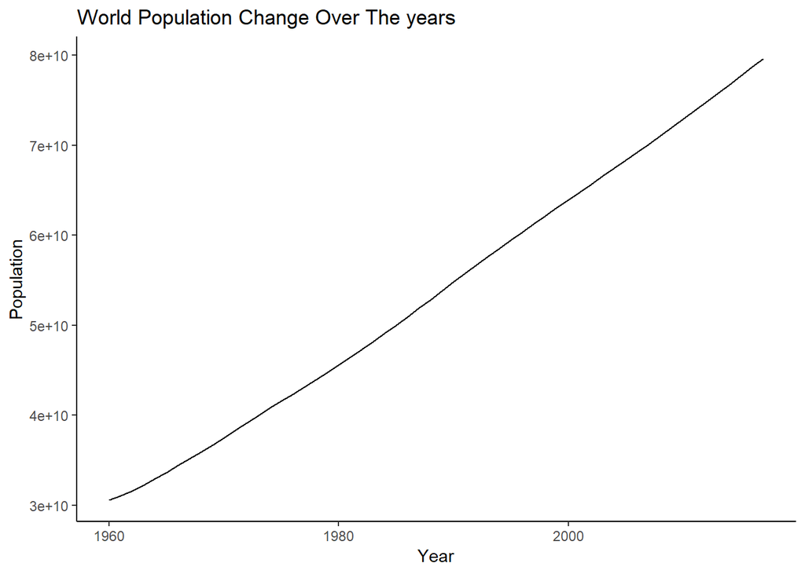

```r
pop %>%
    group_by(Year)%>%
    summarise("Total Population" = sum(Population, na.rm = TRUE))%>%
    ggplot(aes(Year,`Total Population`))+geom_line()+theme_classic()+ggtitle("World Population Change Over The years")+ylab("Population")
```

From the graph we can see that world populatin has increased over the years.

```r
pop %>%
    filter(Year == max(Year))%>%
    arrange(-Population)%>%
    head(30)
```

```
##                                         Country Year Population
## 1                                         World 2017 7530360149
## 2                              IDA & IBRD total 2017 6353204601
## 3                           Low & middle income 2017 6281293921
## 4                                 Middle income 2017 5548845363
## 5                                     IBRD only 2017 4743263932
## 6                    Early-demographic dividend 2017 3213426923
## 7                           Lower middle income 2017 2972642807
## 8                           Upper middle income 2017 2576202556
## 9                           East Asia & Pacific 2017 2314364990
## 10                    Late-demographic dividend 2017 2278227192
## 11  East Asia & Pacific (excluding high income) 2017 2068308373
## 12   East Asia & Pacific (IDA & IBRD countries) 2017 2042783496
## 13                                   South Asia 2017 1788388852
## 14                      South Asia (IDA & IBRD) 2017 1788388852
```

[output cut: 16 more lines]

Top 10 countries with lowest population in 2017

```r
pop %>%
    filter(Year == max(Year))%>%
    arrange(Population)%>%
    head(10)
```

```
##                     Country Year Population
## 1                    Tuvalu 2017      11192
## 2                     Nauru 2017      13649
## 3                     Palau 2017      21729
## 4    British Virgin Islands 2017      31196
## 5  St. Martin (French part) 2017      32125
## 6                San Marino 2017      33400
## 7                 Gibraltar 2017      34571
## 8  Turks and Caicos Islands 2017      35446
## 9             Liechtenstein 2017      37922
## 10                   Monaco 2017      38695
```

Conclusion: We conclude that world population has increased over the years. China and India has the highest population in 2017. Tuvalu has the lowest population in 2017

ï· Your code should be in an R Markdown file, posted to rpubs.com, and should include narrative descriptions of your data cleanup work, analysis, and conclusions.